# No more dividing likelihoods !

Loecher

2026-05-20

## Systematic Comparison via DGP

The goal is benchmarking ARF against a ground-truth Titanic simulation, Here’s a DGP with a distinct distribution for each group:

### What each group stress-tests in ARF

| Group | Distribution | ARF challenge |
| --- | --- | --- |
| female/1 | Bimodal Gaussian | Valley between modes on linear scale |
| male/1 | Bimodal Log Normal | Very difficult |
| female/2 | Power law (1/x²) | Extreme skew, mass near lower bound |
| male/2 | Uniform | Flat density — ARF leaf Gaussians will over-smooth edges |
| female/3 | Gamma | Moderate skew, unimodal — ARF’s 2nd easiest case |
| male/3 | Spike + gamma tail | very different scales |

The uniform and power law cases are particularly interesting diagnostics — ARF’s truncated normal leaves will visibly over-smooth the sharp edges of the uniform, and will struggle with the extreme mass concentration near £5 in the power law.

Global Parameters:

- N = 10^{4}
- n_trees = 200
- min_node_size = 20

# finite_bounds = “local”

## mtry = 1

This is effectively randomized trees.

### Data Generation

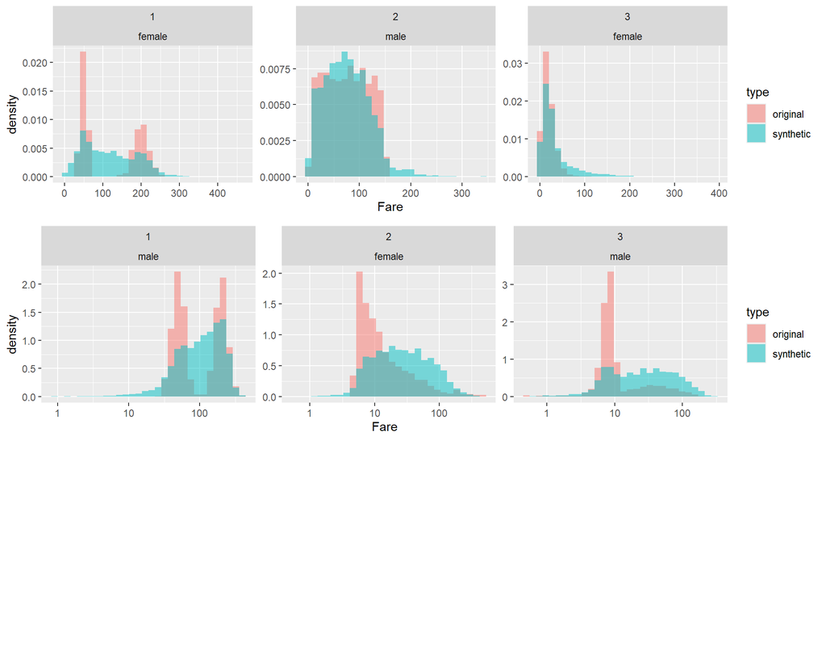

### Likelihood Densities

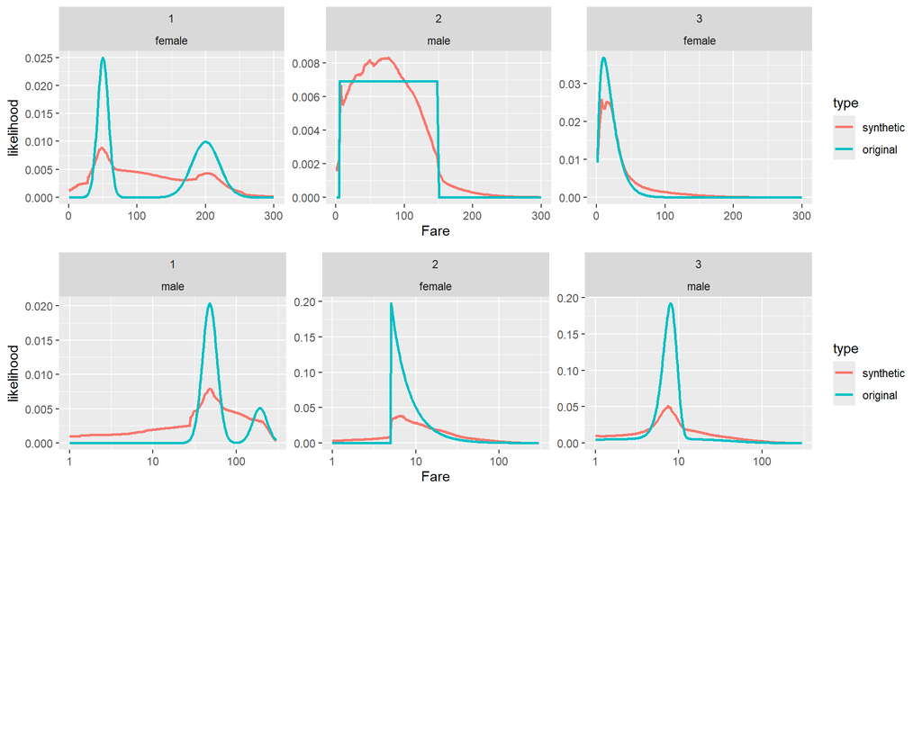

## Forest Diagnostics

.e.g how big are the leafs ?

## mtry = 2

### Data Generation

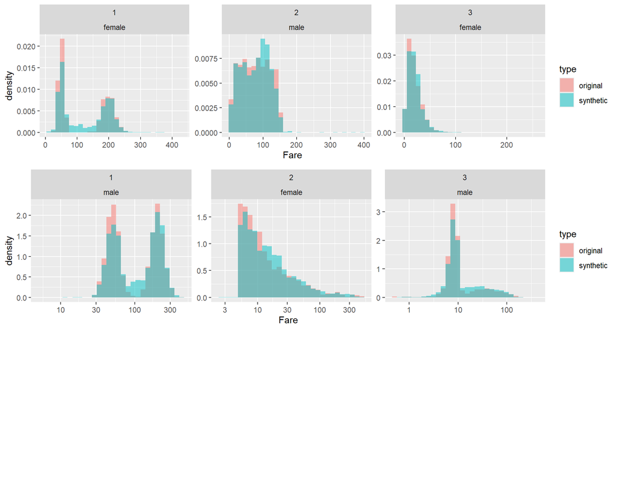

### Likelihood Densities

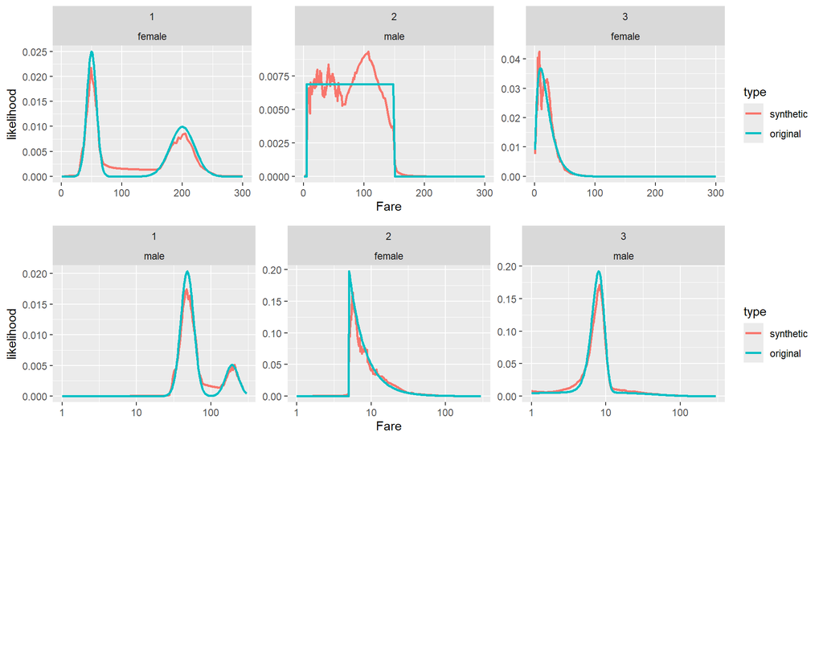

## mtry = 3

This is effectively bagging.

### Data Generation

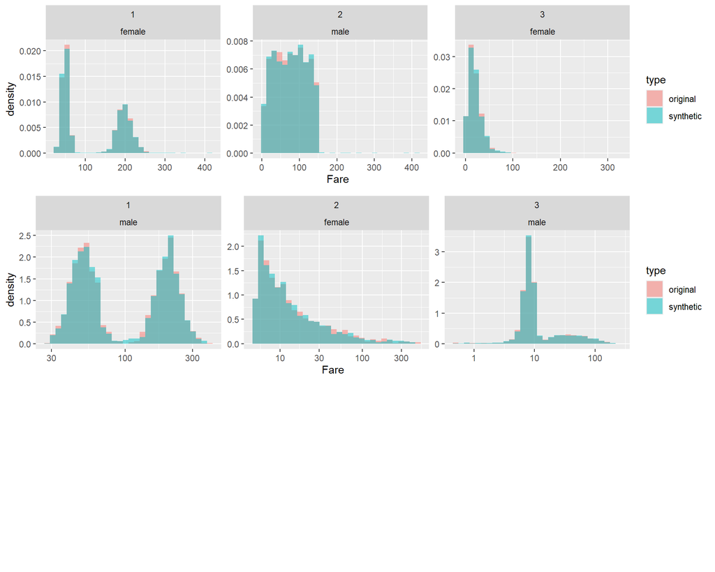

### Likelihood Densities

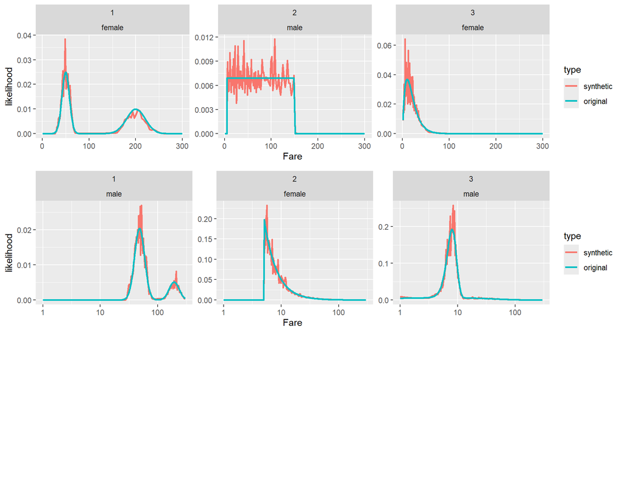

# default finite_bounds (“no”)

This was my original try

## mtry = 1

This is effectively randomized trees.

### Data Generation

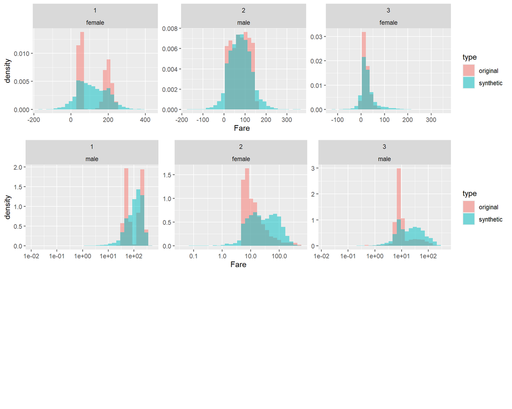

### Likelihood Densities

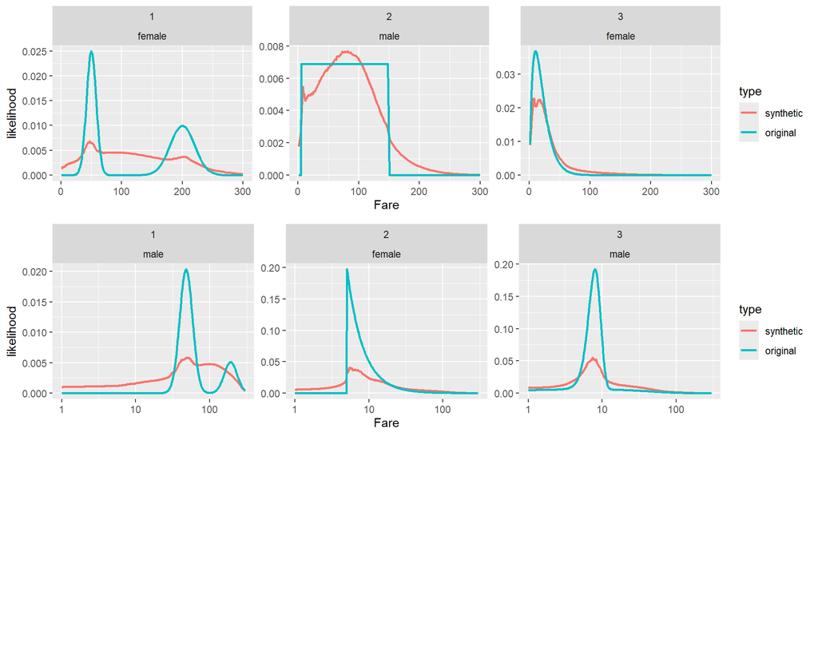

## mtry = 2

### Data Generation

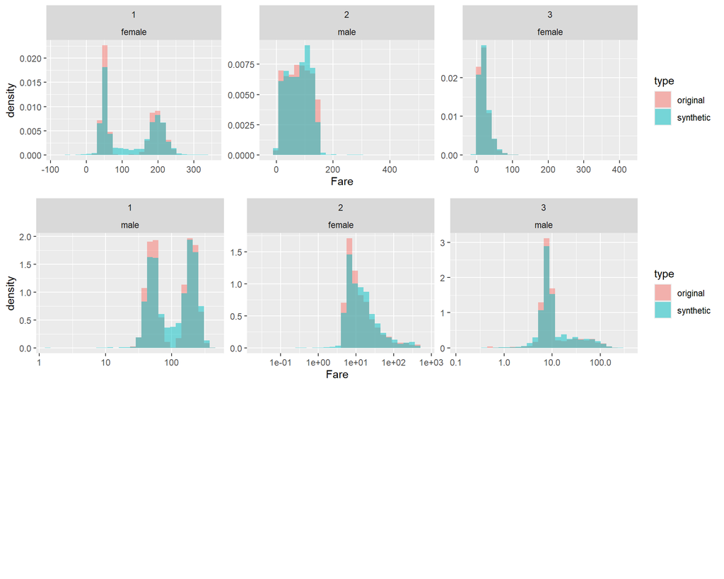

### Likelihood Densities

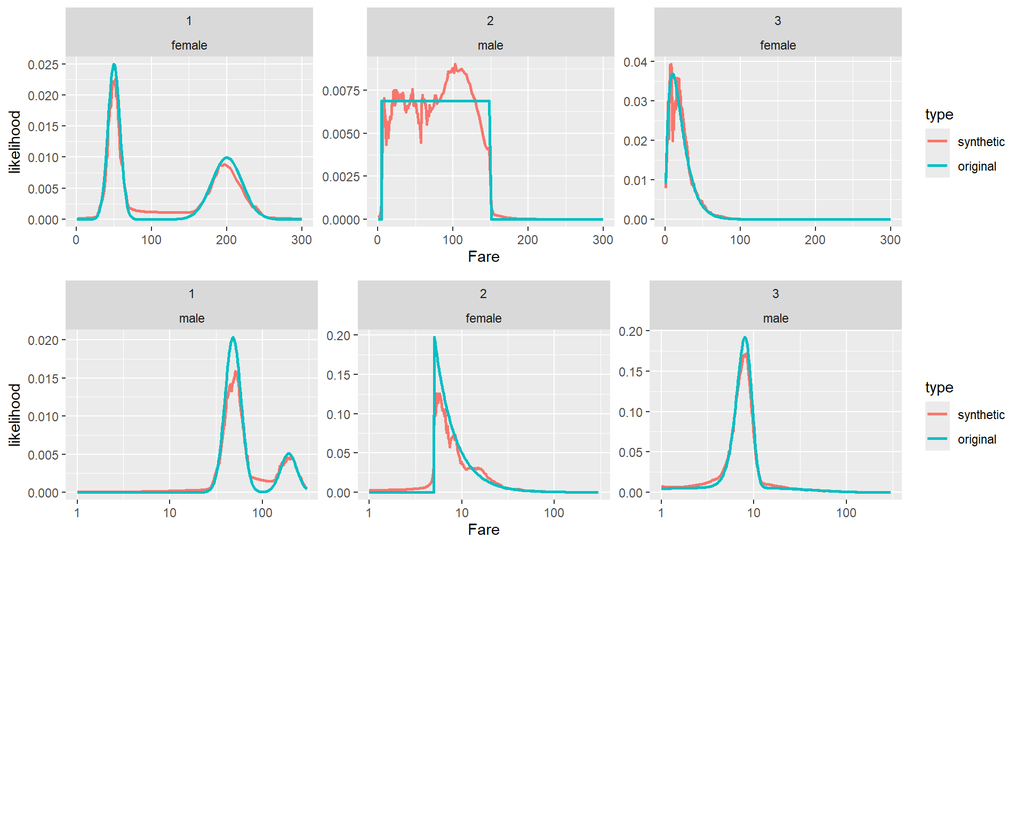

## mtry = 3

This is effectively bagging.

### Data Generation

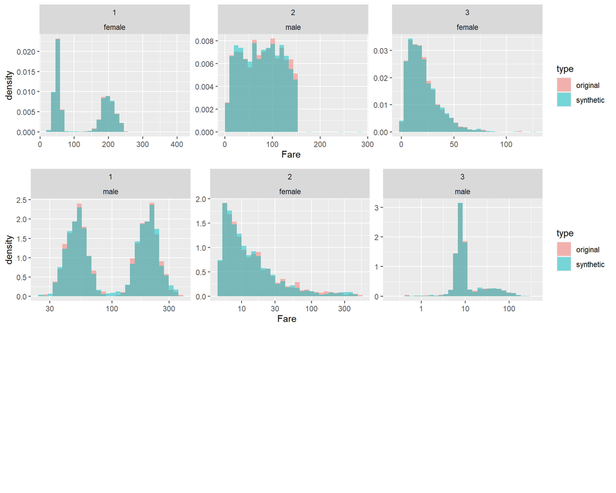

### Likelihood Densities

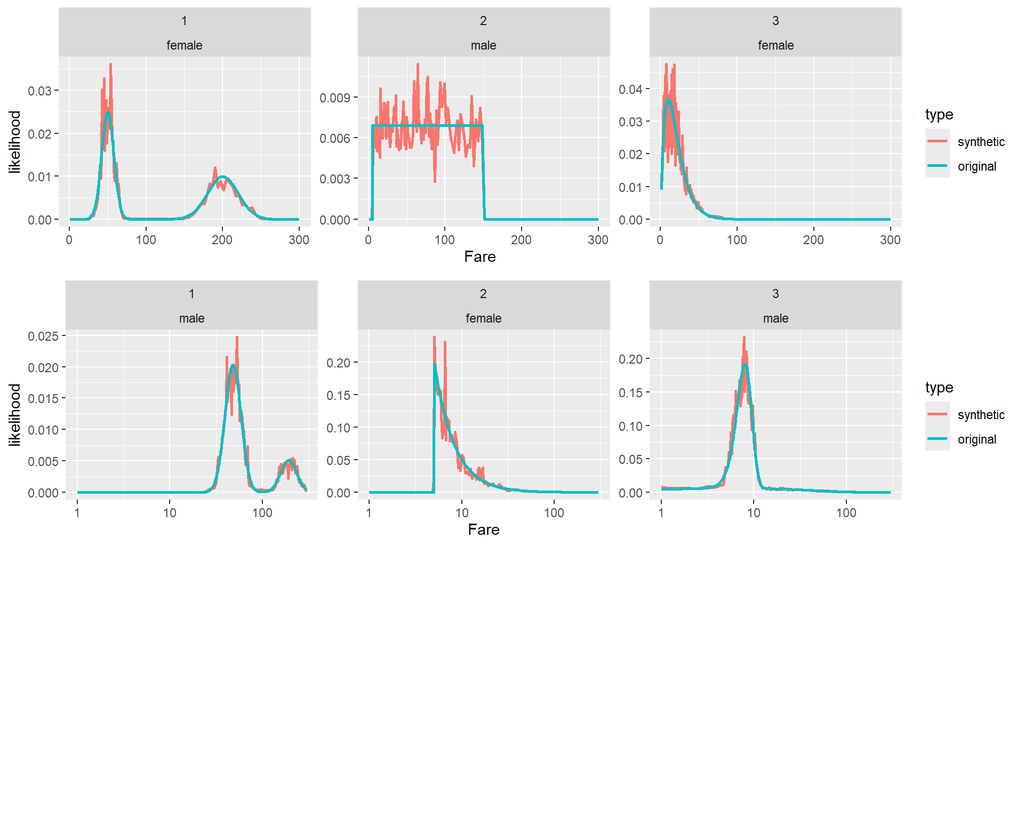

## Diagnostics

#### Leaf Sizes

(Here, I am assuming that sample size multiplied by the “coverage” of the `forest` object returned by `forde` is the leaf size..)

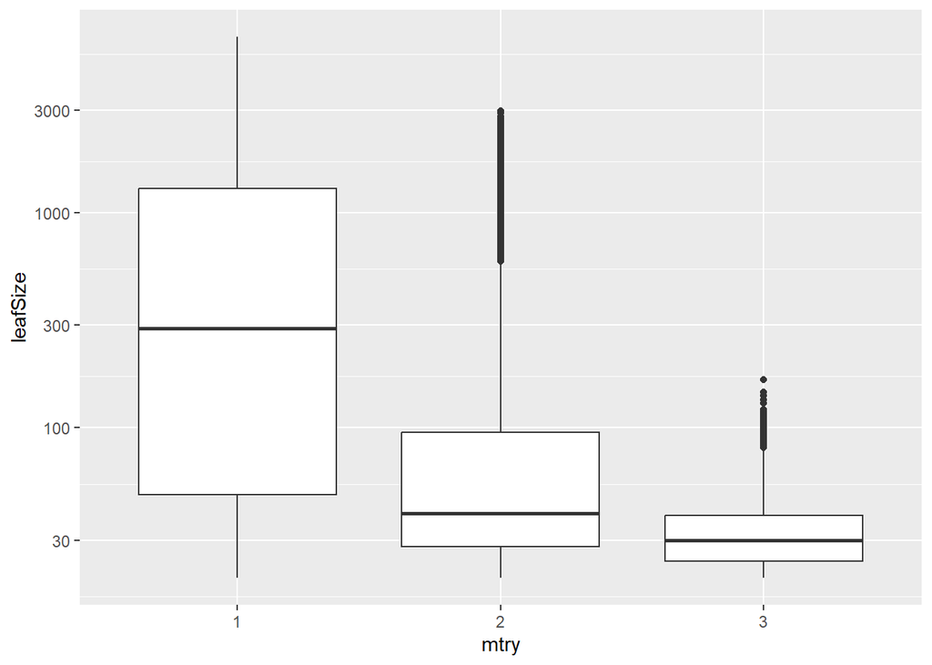

# Conclusions

- Uniform density seems hardest
- Higher `mtry` -> better fit initially followed by “overfitting” of the likelihood.
- The extreme lack of smoothness of the likelihoods is not really visible in the histograms.
- Using the `evidence` argument in `lik()` is MUCH superior to dividing by the marginal likelihoods
  - With hindsight it seems clear why: the marginal likelihoods are likely (no pun) also very noisy; dividing by small, noisy numbers will lead to amplified noise.
- `finite_bounds` does not seem to matter much after all